# Simulation

Ishu Jaswani, Cristian Leo

2022-11-15

# Power of the test

The population considered is the number of students in New York in the academic year 2017-2018 (NYSED Data Site, 2018). Based on this population we want a sample with a statistical power of 90% for an effect size of 0.1. Based on research question 3 will be running a RCT, therefore we can get the minimum sample size to achieve the stated statistical power by running an anova power test with 4 groups, which are the 4 independent variables in our analysis: treatment or control, level of income, gender, and level of education. Based on the test 356 students per group are required to achieve the statistical power desired.

“2018 NY STATE Higher Education Enrollment Data | NYSED Data Site.” Accessed December 5, 2022. https://data.nysed.gov/highered-enrollment.php?year=2018&state=yes.

```r
Uni_studnets_NY <- 1236841

library(pwr)
sample_h1 = pwr.t.test(d = 0.2/2,sig.level = 0.05,power = 0.9,type = "two.sample",alternative = "greater")$n; sample_h1  # based in power of the test, effect size, in each group
```

```
## [1] 1713.446
```

```r
sample_ratio <- sample_h1/Uni_studnets_NY; sample_ratio
```

```
## [1] 0.001385341
```

```r
sample_anova <- pwr.anova.test(k = 4,f = 0.1,sig.level = 0.05,power = 0.9)$n;sample_anova
```

```
## [1] 355.2657
```

```r
#356 in each group
```

# Simulation with effect (1 experiment)

# Survey Questions Simulation

## Survey Question 1

What is your house hold income level? 1) 0-50k 2) 50-150K 3) 150K-300 4) 300+

The household income of students are aound 150k-300k since college tuition is expensive. We are assuming that most students dont take a loan to come to college therefore, dont have extremely now household incomes.

```r
set.seed(224) # randomly generate numbers to remain constant
income_house <- rnorm(n = 360,mean = 150,sd = 100) # normal distribution
max(income_house);min(income_house)
```

```
## [1] 454.7745
```

```
## [1] -77.48633
```

```r
library(Hmisc);library(dplyr);library(forcats)
income_house_sust <- cut(income_house,breaks = c(-Inf,50,150,300,Inf),preset_bins_labels = cut(income_house,breaks = c(-Inf,50,150,300,Inf)),labels =c("0-50k", "50-150k", "150-300k", "300k+"))
fct_count(income_house_sust)
```

```
## # A tibble: 4 × 2
##   f            n
##   <fct>    <int>
## 1 0-50k       70
## 2 50-150k    129
## 3 150-300k   136
## 4 300k+       25
```

## Survery Question 2

What is your gender ? 1) male 2) female

Considering only male and female We have simulated a binomial distribution where there are equal number of males and equal number of females.

```r
set.seed(3)
gender <- factor(rbinom(n=360, size=1, p=0.5), levels = c(0, 1), labels = c("Male", "Female")) # binomial distribution
fct_count(gender)
```

```
## # A tibble: 2 × 2
##   f          n
##   <fct>  <int>
## 1 Male     176
## 2 Female   184
```

## Survery Question 3

What is your education level? 1) undergraduate 2) Graduate 3) MBA 4) PHD

Since there are more undergraduates we have skewed the distribution towards undergraduates. we have used a normal distribution which was centered around 1 and had a standard deviation of 2 and assigned values accordingly so that undergraduates are more and rest are assigned less.

```r
set.seed(2)
edu <- rnorm(n = 360,mean = 1,sd = 2) # normal distribution
max(edu);min(edu)
```

```
## [1] 6.776837
```

```
## [1] -4.440336
```

```r
library(Hmisc);library(dplyr)
edu_sust <- cut(edu,breaks = c(-Inf,1,2,3,Inf),preset_bins_labels = cut(edu,breaks = c(-Inf,1,2,3,Inf)),labels =c("Undergraduate", "Graduate", "MBA", "PHD"))
fct_count(edu_sust)
```

```
## # A tibble: 4 × 2
##   f                 n
##   <fct>         <int>
## 1 Undergraduate   167
## 2 Graduate         64
## 3 MBA              59
## 4 PHD              70
```

## Survey question 4

How often do you shop for new clothing? Answers: Once a week or more; About once a month; A few times a year; Once a year; Never

We have simulated a normal distribution as we understand taht people shopping never are less and people shopping once a week or more also less too. the general audiance lies within the range of once a month and few times a year.

```r
# normal dist
set.seed(1)
often_tr <- rnorm(n = 360,mean = 2.5,sd = 1) # normal distribution
max(often_tr);min(often_tr)
```

```
## [1] 5.149167
```

```
## [1] -0.3889207
```

```r
library(Hmisc);library(dplyr)
often_clothing <- cut(often_tr,breaks = c(-1,1,2,3,4,6),preset_bins_labels = cut(often_tr,breaks = c(-1,1,2,3,4,6)),labels =c("Once a week or more","About once a month","A few times a year","Once a year","Never"))
fct_count(often_clothing)
```

```
## # A tibble: 5 × 2
##   f                       n
##   <fct>               <int>
## 1 Once a week or more    20
## 2 About once a month     76
## 3 A few times a year    150
## 4 Once a year            88
## 5 Never                  26
```

## Survey question 5

Please indicate your level of agreement with the following statement: When given the option, I choose to purchase sustainable products. Answers: Strongly disagree; Somewhat disagree; Neither agree nor disagree; Somewhat agree; Strongly agree

We have used a normal distribution and then assigned values according so that teh distribution is skewed towards somewhat agree and strongly agree as we assume at if people are given the option holding other parameters constant. They would wish to purchase sustainable products

```r
#

library(dplyr);library(Hmisc);library(forcats)
set.seed(1)
agree <- rnorm(n = 360,mean = 4,sd = 1.5)
max(agree);min(agree)
```

```
## [1] 7.97375
```

```
## [1] -0.333381
```

```r
library(Hmisc);library(dplyr)
sust_agree <- cut(agree,breaks = c(-1,1,2,3,4,Inf),preset_bins_labels = cut(agree,breaks = c(-1,1,2,3,4,6)),labels =c("Strongly disagree", "Somewhat disagree", "Neither agree nor disagree", "Somewhat agree", "Strongly agree"))
fct_count(sust_agree)
```

```
## # A tibble: 5 × 2
##   f                              n
##   <fct>                      <int>
## 1 Strongly disagree              7
## 2 Somewhat disagree             22
## 3 Neither agree nor disagree    44
## 4 Somewhat agree               111
## 5 Strongly agree               176
```

## Survey question 6

Please indicate your level of agreement with the following statement: I am willing to pay more for a product that is sustainably produced. Answers: Strongly disagree; Somewhat disagree; Neither agree nor disagree; Somewhat agree; Strongly agree

We assume that the distribution of the likert scale will follow a similar trend - as question 5. As people think that sustainable products are more expensive but it is a step further to saving the enviornment. Therefore they would be willing to pay more in general.

```r
set.seed(2)
pay <- rnorm(n = 360,mean = 4,sd = 1.5)
max(pay);min(pay)
```

```
## [1] 8.332627
```

```
## [1] -0.08025204
```

```r
library(Hmisc);library(dplyr)
sust_pay <- cut(pay,breaks = c(-1,1,2,3,4,Inf),preset_bins_labels = cut(pay,breaks = c(-1,1,2,3,4,6)),labels =c("Strongly disagree", "Somewhat disagree", "Neither agree nor disagree", "Somewhat agree", "Strongly agree"))
fct_count(sust_pay)
```

```
## # A tibble: 5 × 2
##   f                              n
##   <fct>                      <int>
## 1 Strongly disagree              7
## 2 Somewhat disagree             24
## 3 Neither agree nor disagree    52
## 4 Somewhat agree                84
## 5 Strongly agree               193
```

## Survey Question 7

Please indicate your level of agreement with the following statement: When retail shopping, I look at the tags and other available information to determine if the article of clothing to determine if it was produced sustainably. Answers: Strongly disagree; Somewhat disagree; Neither agree nor disagree; Somewhat agree; Strongly agree

```r
set.seed(2)
info_tags <- rnorm(n = 360,mean = 1,sd = 2)
max(info_tags);min(info_tags)
```

```
## [1] 6.776837
```

```
## [1] -4.440336
```

```r
library(Hmisc);library(dplyr)
info_tags_sust <- cut(info_tags,breaks = c(-Inf,1,2,3,4,Inf),preset_bins_labels = cut(info_tags,breaks = c(-Inf,1,2,3,4,Inf)),labels =c("Strongly disagree", "Somewhat disagree", "Neither agree nor disagree", "Somewhat agree", "Strongly agree"))
fct_count(info_tags_sust)
```

```
## # A tibble: 5 × 2
##   f                              n
##   <fct>                      <int>
## 1 Strongly disagree            167
## 2 Somewhat disagree             64
## 3 Neither agree nor disagree    59
## 4 Somewhat agree                35
## 5 Strongly agree                35
```

## Survey Question 8

Please indicate your level of agreement with the following statement: #rephrase When a company adopts sustainable business practices, I will go out of my way to buy their products. Answers: Strongly disagree; Somewhat disagree; Neither agree nor disagree; Somewhat agree; Strongly agree

Question 5 aims to identify in what extent sustainability is a purchasing criteria. On a scale from 1 to 5, where 1 is “Strongly disagree”, and 5 is “Strongly agree”, we assume that most of the responses will focus on the slight right of middle of the scale. Indeed, our assumed mean is 3.3 and standard deviation 2. We used a random normal distribution to assure a distribution focused on the mean and with tails on the extremes.

```r
set.seed(3)
extra_effort <- rnorm(n = 360,mean = 3.3,sd = 2)
max(extra_effort);min(extra_effort)
```

```
## [1] 10.3386
```

```
## [1] -1.507327
```

```r
library(Hmisc);library(dplyr);library(forcats)
sust_extra_effort <- cut(extra_effort,breaks = c(-Inf,1,2,3,4,Inf),preset_bins_labels = cut(extra_effort,breaks = c(-Inf,1,2,3,4,Inf)),labels =c("Strongly disagree", "Somewhat disagree", "Neither agree nor disagree", "Somewhat agree", "Strongly agree"))
fct_count(sust_extra_effort)
```

```
## # A tibble: 5 × 2
##   f                              n
##   <fct>                      <int>
## 1 Strongly disagree             42
## 2 Somewhat disagree             52
## 3 Neither agree nor disagree    62
## 4 Somewhat agree                68
## 5 Strongly agree               136
```

## Survey Question 9

Question 6 is a customized question, which will show a t-shirt with a description. In the treatment group the description will mention that the t-shirt is made by sustainable fabrics and the company operates following environmental sustainable practices. In the control group the same t-shirt will be displayed, but this time the description will mention that the t-shirt and the company that produced are not sustainable. In the survey will be given the possibility to the survey takers to drag a point in the bar from 0 to 50 to indicate how much is the given t-shirt worth it. We assume that the respondents in the treatment group will answer with a higher price on average. Therefore, the distribution in the control group will be right skewed with a lower mean and concentration of price given, while the treatment group will report the opposite. To do so, we used a Chi-squared distribution with 20 degrees of freedom for the control group and a skewed random normal distribution with a skewness parameter of 0.5 with the rsnorm function from the “fGarch” library.

```r
# control
set.seed(3)
cont_price <-as.integer(rchisq(n = 180,df = 20)); min(cont_price);max(cont_price)
```

```
## [1] 7
```

```
## [1] 39
```

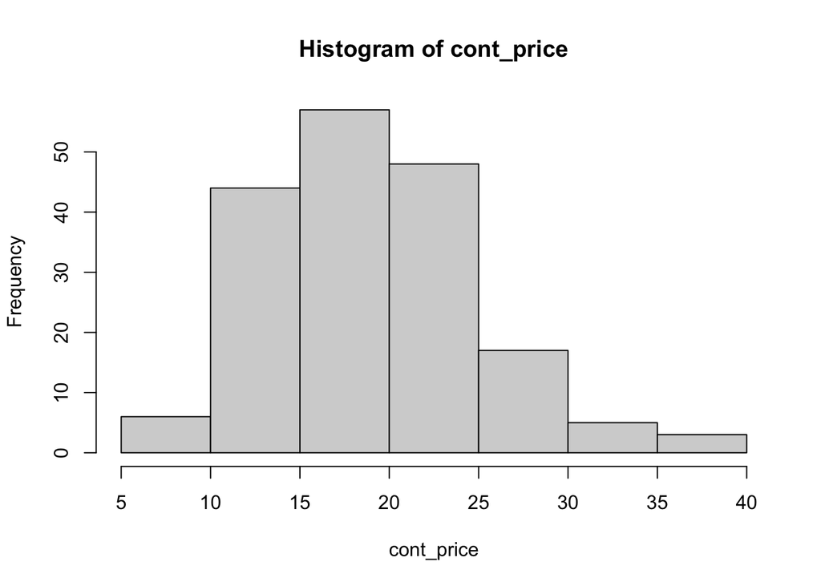

```r
hist(cont_price)
```

```r
# treatment
library(fGarch)
set.seed(2)
treat_price <- as.integer(rsnorm(180, 40, 5, 0.5)); min(treat_price);max(treat_price)
```

```
## [1] 23
```

```
## [1] 48
```

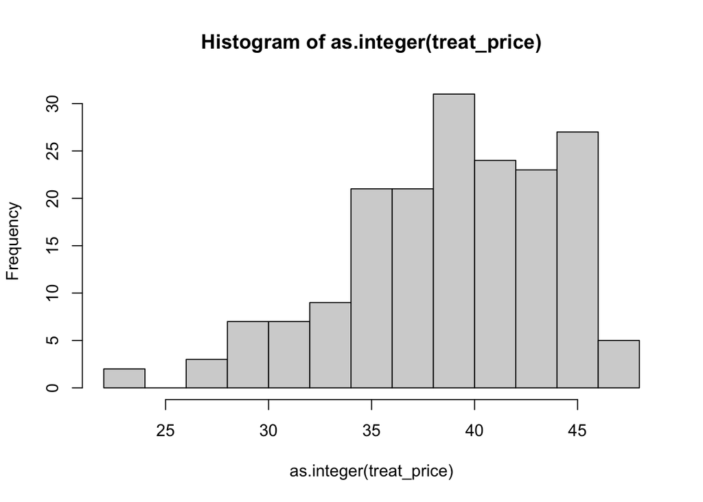

```r
hist(as.integer(treat_price))
```

## Survey Question 10

Treatment group: Would you be willing to buy the same shirt for $40? Answers: Yes; No

Control group: Would you be willing to buy the same shirt for $40? Answers: Yes; No

Following question 6, question 7 is a customized question as well. However, if question 6 measures the price perception of the t-shirt, question 7 measures the willingness to buy given the same price both for the treatment group and the control group. We assume that the proportion of “Yes” in the treatment group is higher than the proportion of “Yes” in the control group. Moreover, we state a meaningful difference of roughly 40%, in order to be compelling for the companies to switch their production from non sustainable to sustainable. To simulate the results we used a random binomial distribution with probability of 0.3 in the control group and 0.6999 in the treatment group.

```r
# control
set.seed(3)
cont_buy <- as.factor(rbinom(n = 180,size = 1,prob = 0.3))
cont_buy <- fct_recode(cont_buy,"Yes"="1","No"="0")
fct_count(cont_buy)
```

```
## # A tibble: 2 × 2
##   f         n
##   <fct> <int>
## 1 No      126
## 2 Yes      54
```

```r
# treatment
set.seed(12029)
treat_buy <- as.factor(rbinom(n = 180,size = 1,prob = 0.6999))
treat_buy <- fct_recode(treat_buy,"Yes"="1","No"="0")
fct_count(treat_buy)
```

```
## # A tibble: 2 × 2
##   f         n
##   <fct> <int>
## 1 No       52
## 2 Yes     128
```

## Survey Question 11

Do you believe the quality of sustainably produced clothing is higher than non-sustainably produced clothing? Answers: Yes; No; I don’t know

Question 8 allows us to understand a deeper insights on why a sustainable product is worthed more than a non sustainable one. We assume that one of the main reason is a higher quality of the product. Therefore, we may expect a higher proportion of yes both in the treatment and control group. To achieve that, we simulated the data with a random normal distribution with mean 1 and standard deviation of 0.8. Then we binned the numbers generated by the random normal distribution with the possible answers, where numbers up to 1 mean “Yes”, 1 to 2 mean “No”, and greater than 2 mean “I don’t know”.

```r
set.seed(2)
quality <- rnorm(n = 360,mean = 1,sd = 0.8)
max(quality);min(quality)
```

```
## [1] 3.310735
```

```
## [1] -1.176134
```

```r
library(Hmisc);library(dplyr)
quality_sust <- cut(quality,breaks = c(-Inf,1,2,Inf),preset_bins_labels = cut(quality,breaks = c(-Inf,1,2,Inf)),labels =c("Yes","No","I don't Know"))
fct_count(quality_sust)
```

```
## # A tibble: 3 × 2
##   f                n
##   <fct>        <int>
## 1 Yes            167
## 2 No             146
## 3 I don't Know    47
```

# Simulation Dataset

```r
main_data <- data.frame(index = 1:360,often_clothing,sust_agree,sust_pay,info_tags_sust,sust_extra_effort,quality_sust,edu_sust,gender,income_house_sust)
colnames(main_data)
```

```
##  [1] "index"             "often_clothing"    "sust_agree"
##  [4] "sust_pay"          "info_tags_sust"    "sust_extra_effort"
##  [7] "quality_sust"      "edu_sust"          "gender"
## [10] "income_house_sust"
```

```r
set.seed(20)
main_data <- main_data %>%
  mutate(z = row_number() %in% sample(n(), n() / 2) )

skimr::skim(main_data)
```

Data summary

| Name | main_data |
| --- | --- |
| Number of rows | 360 |
| Number of columns | 11 |
| _______________________ |  |
| Column type frequency: |  |
| factor | 9 |
| logical | 1 |
| numeric | 1 |
| ________________________ |  |
| Group variables | None |

**Variable type: factor**

| skim_variable | n_missing | complete_rate | ordered | n_unique | top_counts |
| --- | --- | --- | --- | --- | --- |
| often_clothing | 0 | 1 | FALSE | 5 | A f: 150, Onc: 88, Abo: 76, Nev: 26 |
| sust_agree | 0 | 1 | FALSE | 5 | Str: 176, Som: 111, Nei: 44, Som: 22 |
| sust_pay | 0 | 1 | FALSE | 5 | Str: 193, Som: 84, Nei: 52, Som: 24 |
| info_tags_sust | 0 | 1 | FALSE | 5 | Str: 167, Som: 64, Nei: 59, Som: 35 |
| sust_extra_effort | 0 | 1 | FALSE | 5 | Str: 136, Som: 68, Nei: 62, Som: 52 |
| quality_sust | 0 | 1 | FALSE | 3 | Yes: 167, No: 146, I d: 47 |
| edu_sust | 0 | 1 | FALSE | 4 | Und: 167, PHD: 70, Gra: 64, MBA: 59 |
| gender | 0 | 1 | FALSE | 2 | Fem: 184, Mal: 176 |
| income_house_sust | 0 | 1 | FALSE | 4 | 150: 136, 50-: 129, 0-5: 70, 300: 25 |

**Variable type: logical**

| skim_variable | n_missing | complete_rate | mean | count |
| --- | --- | --- | --- | --- |
| z | 0 | 1 | 0.5 | FAL: 180, TRU: 180 |

**Variable type: numeric**

| skim_variable | n_missing | complete_rate | mean | sd | p0 | p25 | p50 | p75 | p100 | hist |
| --- | --- | --- | --- | --- | --- | --- | --- | --- | --- | --- |
| index | 0 | 1 | 180.5 | 104.07 | 1 | 90.75 | 180.5 | 270.25 | 360 | ▇▇▇▇▇ |

```r
main_data <- main_data |>
  arrange(z)

main_data <- main_data |>
  mutate(price = c(cont_price,treat_price),buy=c(cont_buy,treat_buy))

main_data
```

```
##     index      often_clothing                 sust_agree
## 1       1  About once a month             Somewhat agree
## 2       4               Never             Strongly agree
## 3       7  A few times a year             Strongly agree
## 4      11               Never             Strongly agree
## 5      15         Once a year             Strongly agree
## 6      17  A few times a year             Somewhat agree
## 7      23  A few times a year             Strongly agree
## 8      24 Once a week or more          Somewhat disagree
## 9      25         Once a year             Strongly agree
## 10     27  A few times a year             Somewhat agree
## 11     28  About once a month          Somewhat disagree
## 12     30  A few times a year             Strongly agree
## 13     31         Once a year             Strongly agree
## 14     32  A few times a year             Somewhat agree
```

[output cut: 1429 more lines]

# Statistical Analysis Simulation with effect (1 experiment)

## Research Question 1

Do sustainable labels influence people’s perception about products’ perceived price?

In the first research question we examine whether the sustainability of a product affects the customer perception about the products’ perceived price. To do so we analyze the answers of the question 10 of the survey with a prop test.

```r
main_data |>
  select(z,buy)|>
  table()
```

```
##        buy
## z        No Yes
##   FALSE 126  54
##   TRUE   52 128
```

```r
rq1 <- prop.test(x = c(128,54),n=c(180,180),alternative = "greater")

effect_size_rq1 <- prop.test(x = c(128,54),n=c(180,180),alternative = "greater")$estimate; (effect_size_rq1[1]-effect_size_rq1[2])*100 # in percentage%
```

```
##   prop 1
## 41.11111
```

## Research Question 2

Do people willing to pay a higher price for a product if it comes with a sustainable label? If so, to what degree?

The second research questions aims to provide an actionable insight for the companies. Indeed, the goal of this study is to compel the companies to switch their operations into a sustainable way.

```r
rq2 <- t.test(x=main_data[main_data$z == 1, ]$price,y=main_data[main_data$z == 0, ]$price,alternative = "greater")

effect_size_rq2 <- t.test(x=main_data[main_data$z == 1, ]$price,y=main_data[main_data$z == 0, ]$price,alternative = "greater")$estimate; (effect_size_rq2[1]-effect_size_rq2[2])
```

```
## mean of x
##  19.81111
```

## Research Question 3 - binary outcome

Do gender, education and household income level af- fect the influences of sustainability tags on people’s willingness to purchase?

```r
library(tidyverse);library(broom)
main_data_hilo <- main_data %>%
  mutate(price_hilo = factor(ifelse(price >= mean(price), 1, 0), levels = c(0, 1)))
model <- glm(price_hilo~z+edu_sust+income_house_sust+gender,data=main_data_hilo, family = "binomial")
pred <- predict(model, type='response')
pred_hilo <- ifelse(pred>0.5, 1, 0)

prop.table(table(pred = pred_hilo, true = main_data_hilo$price_hilo))
```

```
##     true
## pred          0          1
##    0 0.46944444 0.03055556
##    1 0.02500000 0.47500000
```

```r
summary(model)
```

```
##
## Call:
## glm(formula = price_hilo ~ z + edu_sust + income_house_sust +
##     gender, family = "binomial", data = main_data_hilo)
##
## Deviance Residuals:
##     Min       1Q   Median       3Q      Max
## -2.6213  -0.3170   0.1513   0.2876   2.6120
##
## Coefficients:
##                           Estimate Std. Error z value Pr(>|z|)
## (Intercept)                -2.1802     0.6258  -3.484 0.000494 ***
## zTRUE                       6.2122     0.5724  10.853  < 2e-16 ***
## edu_sustGraduate            0.4322     0.6962   0.621 0.534760
## edu_sustMBA                -0.6157     0.6889  -0.894 0.371472
## edu_sustPHD                 0.8853     0.6329   1.399 0.161862
## income_house_sust50-150k   -0.7855     0.6472  -1.214 0.224840
## income_house_sust150-300k  -0.6292     0.6434  -0.978 0.328157
## income_house_sust300k+     -0.5241     1.0624  -0.493 0.621828
## genderFemale               -0.8440     0.5066  -1.666 0.095703 .
## ---
## Signif. codes:  0 '***' 0.001 '**' 0.01 '*' 0.05 '.' 0.1 ' ' 1
##
## (Dispersion parameter for binomial family taken to be 1)
##
##     Null deviance: 499.02  on 359  degrees of freedom
## Residual deviance: 145.30  on 351  degrees of freedom
## AIC: 163.3
##
## Number of Fisher Scoring iterations: 6
```

## Research Question 3 - continuous outcome

```r
main_data$z <- as.factor(main_data$z)

model <- lm(price~z+edu_sust +income_house_sust+gender,data=main_data)
summary(model)
```

```
##
## Call:
## lm(formula = price ~ z + edu_sust + income_house_sust + gender,
##     data = main_data)
##
## Residuals:
##      Min       1Q   Median       3Q      Max
## -17.1860  -3.7582   0.0873   3.9298  19.2614
##
## Coefficients:
##                           Estimate Std. Error t value Pr(>|t|)
## (Intercept)                18.6841     0.8537  21.885   <2e-16 ***
## zTRUE                      19.8529     0.5981  33.193   <2e-16 ***
## edu_sustGraduate            0.1924     0.8369   0.230    0.818
## edu_sustMBA                -0.3340     0.8559  -0.390    0.697
## edu_sustPHD                 0.7868     0.8085   0.973    0.331
## income_house_sust50-150k    0.4782     0.8392   0.570    0.569
## income_house_sust150-300k   0.6580     0.8338   0.789    0.431
## income_house_sust300k+      0.8281     1.3185   0.628    0.530
## genderFemale                0.3840     0.5980   0.642    0.521
## ---
## Signif. codes:  0 '***' 0.001 '**' 0.01 '*' 0.05 '.' 0.1 ' ' 1
##
## Residual standard error: 5.641 on 351 degrees of freedom
## Multiple R-squared:  0.7602, Adjusted R-squared:  0.7547
## F-statistic: 139.1 on 8 and 351 DF,  p-value: < 2.2e-16
```

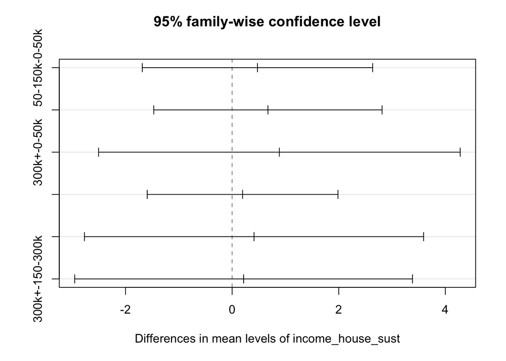

```r
model_anov <- aov(price~z+edu_sust +income_house_sust+gender,data=main_data)

t1 <- TukeyHSD(model_anov,which = "income_house_sust" ,conf.level=.95)$income_house_sust

t2 <- TukeyHSD(model_anov,which = "z" ,conf.level=.95)$z

t3 <- TukeyHSD(model_anov,which = "edu_sust" ,conf.level=.95)$edu_sust

t4 <- TukeyHSD(model_anov,which = "gender" ,conf.level=.95)$gender

t5 <- rbind(t2,t1,t3,t4)


plot(TukeyHSD(model_anov,which = "income_house_sust" ,conf.level=.95))
```

```r
tidy(anova(object = model))
```

```
## # A tibble: 5 × 6
##   term                 df   sumsq   meansq statistic    p.value
##   <chr>             <int>   <dbl>    <dbl>     <dbl>      <dbl>
## 1 z                     1 35323.  35323.    1110.     9.72e-111
## 2 edu_sust              3    43.1    14.4      0.452  7.16e-  1
## 3 income_house_sust     3    25.4     8.46     0.266  8.50e-  1
## 4 gender                1    13.1    13.1      0.412  5.21e-  1
## 5 Residuals           351 11169.     31.8     NA     NA
```

```r
class(tidy(model))
```

```
## [1] "tbl_df"     "tbl"        "data.frame"
```

```r
tidy(model) |>
  select(estimate,p.value) |>
  mutate(i = seq(1,9,1)) |>
  filter(i==1) |>
  select(estimate,p.value)
```

```
## # A tibble: 1 × 2
##   estimate  p.value
##      <dbl>    <dbl>
## 1     18.7 1.43e-67
```

# Simulation with effect (1000 experiments)

## Level of Income

```r
set.seed(4172)
B <- 1000 # number of experiments to replicate
# put above experiment into function for replication
experiment <- function(n = 360) {
  y_0 <- rnorm(n = n, mean = 150, sd = 100) %>% round(digits = 1)
  tibble(y_0)
}
# per notes, which is less intuitive (reads like one experiment, size 60 * 1000)
income_house <- experiment(n = 360 * B) %>% mutate(i = rep(seq(B), each = 360) )
max(income_house);min(income_house)
```

```
## [1] 1000
```

```
## [1] -288.5
```

```r
library(Hmisc);library(dplyr)
income_house_sust <- cut(income_house$y_0,breaks = c(-Inf,50,150,300,Inf),preset_bins_labels = cut(income_house,breaks = c(-Inf,50,150,300,Inf)),labels =c("0-50k", "50-150k", "150-300k", "300k+"))
 fct_count(income_house_sust)
```

```
## # A tibble: 4 × 2
##   f             n
##   <fct>     <int>
## 1 0-50k     57178
## 2 50-150k  122459
## 3 150-300k 156197
## 4 300k+     24166
```

## Gender

```r
fct_count(as.vector(replicate(1000,factor(rbinom(n = 360, size = 1, p=0.5), levels = c(0, 1), labels = c("Male", "Female")))))
```

```
## # A tibble: 2 × 2
##   f           n
##   <fct>   <int>
## 1 Female 180145
## 2 Male   179855
```

```r
rep(seq(1000),each = 360)
```

[output not shown]

[output cut: 5542 more lines]

```r
library(tidyverse)
library(broom)
B <- 1000 # number of experiments to replicate
# put above experiment into function for replication
analyze_experiment <- function(y_1 , y_0) {
  prop.test(x= c(y_1,y_0), n=c(360/2,360/2), alternative = 'greater') %>%
  tidy() |>
  mutate(effect = estimate1-estimate2) |>
  select(effect_size = effect, upper_ci = conf.high, p = p.value)
}
experiment <- function(n = 360) {
  y_0 <- factor(rbinom(n = n/2, size = 1, p=0.5), levels = c(0, 1), labels = c("Male", "Female"))
  y_1 <- factor(rbinom(n = n/2, size = 1, p=0.5), levels = c(0, 1), labels = c("Male", "Female"))
  tibble(y_0, y_1 )
}
# per notes, which is less intuitive (reads like one experiment, size 60 * 1000)
Gender_simulation   <- experiment(n = 360 * B) %>% mutate(i = rep(seq(B), each = 180) )
# run test on each experiment

x <- Gender_simulation %>% group_by(i,y_1) |> summarise(no_rows = length(y_1))
y <- Gender_simulation %>% group_by(i,y_0) |> summarise(no_rows = length(y_0))

Gender_simulation <- cbind(x,y)
results <- Gender_simulation |>
  filter(y_1 =="Male") |>
  select(no_rows...3, no_rows...6) |>    # row 3 is treatment and row 6 is control
  mutate(i = rep(seq(B), each = 1) ) |>
  group_by(i) |>
  summarise(analyze_experiment(no_rows...3,no_rows...6))


mean(results$p < 0.05)
```

```
## [1] 0.04
```

```r
summary(results$effect_size)
```

```
##     Min.  1st Qu.   Median     Mean  3rd Qu.     Max.
## -0.22222 -0.03333  0.00000  0.00020  0.03333  0.17778
```

```r
summary(results$upper_ci)
```

```
##    Min. 1st Qu.  Median    Mean 3rd Qu.    Max.
##       1       1       1       1       1       1
```

# Statistical Analysis Simulation with effect (experiment = 1000)

## Research Question 1

```r
library(tidyverse)
library(broom);library(dplyr)
set.seed(2)
B <- 1000 # number of experiments to replicate
# put above experiment into function for replication
analyze_experiment <- function(y_1 , y_0) {
  prop.test(x= c(y_0,y_1), n=c(360/2,360/2), alternative = 'greater') %>%
  tidy() |>
  mutate(effect = estimate1-estimate2) |>
  select(effect_size = effect, upper_ci = conf.high, p = p.value)
}
experiment <- function(n = 360) {
  y_0 <- factor(rbinom(n = n/2,size = 1,prob = 0.3), levels = c(0, 1),  labels = c("Yes", "No"))
  y_1 <- factor(rbinom(n = n/2,size = 1,prob = 0.6999), levels = c(0, 1),  labels = c("Yes", "No"))
  tibble(y_0, y_1 )
}

buy_simulation   <- experiment(n = 360 * B) %>% mutate(i = rep(seq(B), each = 360/2) )
# run test on each experiment

x <- buy_simulation %>% group_by(i,y_1) |> summarise(no_rows = length(y_1))
y <- buy_simulation %>% group_by(i,y_0) |> summarise(no_rows = length(y_0))

buy_simulation <- cbind(x,y)
results <- buy_simulation |>
  filter(y_1 =="Yes") |>
  select(no_rows...3, no_rows...6) |>    # row 3 is control and row 6 is test
  mutate(i = rep(seq(B), each = 1) ) |>
  group_by(i) |>
  summarise(analyze_experiment(no_rows...3,no_rows...6))


mean(results$p > 0.05)
```

```
## [1] 0
```

```r
summary(results$effect_size)
```

```
##    Min. 1st Qu.  Median    Mean 3rd Qu.    Max.
##  0.2444  0.3611  0.3944  0.3968  0.4278  0.5667
```

```r
summary(results$upper_ci)
```

```
##    Min. 1st Qu.  Median    Mean 3rd Qu.    Max.
##       1       1       1       1       1       1
```

## Research Question 2

```r
set.seed(4172)
B_2 <- 1000 # number of experiments to replicate
# put above experiment into function for replication
experiment <- function(n = 360) {
  y_0 <- as.integer(rchisq(n = n/2,df = 20))
  y_1 <- as.integer(rsnorm(n/2, 40, 5, 0.5))
  tibble(y_0, y_1 )
}

analyze_experiment <- function(y_1, y_0) {
  t.test(x = y_1, y = y_0, alternative = 'less') %>%
  tidy() %>%
  select(effect = estimate, upper_ci = conf.high, p = p.value)
}


# per notes, which is less intuitive (reads like one experiment, size 60 * 1000)
d_rep   <- experiment(n = 360 * B_2) %>% mutate(i = rep(seq(B), each = 360/2) )
# run test on each experiment
results <- d_rep %>% group_by(i) %>% summarise( analyze_experiment(y_1, y_0) )
# same summaries as in notes; but can do whatever you want
mean(results$p < 0.05)
```

```
## [1] 0
```

```r
summary(results$effect)
```

```
##    Min. 1st Qu.  Median    Mean 3rd Qu.    Max.
##   17.47   19.62   20.02   20.03   20.43   22.53
```

```r
summary(results$upper_ci)
```

```
##    Min. 1st Qu.  Median    Mean 3rd Qu.    Max.
##   18.53   20.63   21.02   21.02   21.41   23.46
```

# Simulation with no effect

## Survey Question 1

```r
set.seed(224) # randomly generate numbers to remain constant
income_house <- rnorm(n = 360,mean = 180,sd = 100) # normal distribution
max(income_house);min(income_house)
```

```
## [1] 484.7745
```

```
## [1] -47.48633
```

```r
library(Hmisc);library(dplyr)
income_house_sust <- cut(income_house,breaks = c(-Inf,50,180,360,Inf),preset_bins_labels = cut(income_house,breaks = c(-Inf,50,180,360,Inf)),labels =c("0-50k", "50-180k", "180-360k", "360k+"))
fct_count(income_house_sust)
```

```
## # A tibble: 4 × 2
##   f            n
##   <fct>    <int>
## 1 0-50k       40
## 2 50-180k    159
## 3 180-360k   145
## 4 360k+       16
```

## Survery Question 2

```r
set.seed(3)
gender <- factor(rbinom(n=360, size=1, p=0.5), levels = c(0, 1), labels = c("Male", "Female")) # binomial distribution
fct_count(gender)
```

```
## # A tibble: 2 × 2
##   f          n
##   <fct>  <int>
## 1 Male     176
## 2 Female   184
```

## Survery Question 3

```r
set.seed(2)
edu <- rnorm(n = 360,mean = 2.5,sd = 2) # normal distribution
max(edu);min(edu)
```

```
## [1] 8.276837
```

```
## [1] -2.940336
```

```r
library(Hmisc);library(dplyr)
edu_sust <- cut(edu,breaks = c(-Inf,1,2,3,Inf),preset_bins_labels = cut(edu,breaks = c(-Inf,1,2,3,Inf)),labels =c("Undergraduate", "Graduate", "MBA", "PHD"))
fct_count(edu_sust)
```

```
## # A tibble: 4 × 2
##   f                 n
##   <fct>         <int>
## 1 Undergraduate    77
## 2 Graduate         64
## 3 MBA              54
## 4 PHD             165
```

## Survey question 4

```r
# normal dist
set.seed(1)
often_tr <- rnorm(n = 360,mean = 2.5,sd = 2) # normal distribution
max(often_tr);min(often_tr)
```

```
## [1] 7.798334
```

```
## [1] -3.277841
```

```r
library(Hmisc);library(dplyr)
often_clothing <- cut(often_tr,breaks = c(-1,1,2,3,4,6),preset_bins_labels = cut(often_tr,breaks = c(-1,1,2,3,4,6)),labels =c("Once a week or more","About once a month","A few times a year","Once a year","Never"))
fct_count(often_clothing)
```

```
## # A tibble: 6 × 2
##   f                       n
##   <fct>               <int>
## 1 Once a week or more    53
## 2 About once a month     76
## 3 A few times a year     69
## 4 Once a year            68
## 5 Never                  67
## 6 <NA>                   27
```

## Survey question 5

```r
#

library(dplyr);library(Hmisc);library(forcats)
set.seed(1)
agree <- rnorm(n = 360,mean = 2.5,sd = 2)
max(agree);min(agree)
```

```
## [1] 7.798334
```

```
## [1] -3.277841
```

```r
library(Hmisc);library(dplyr)
sust_agree <- cut(agree,breaks = c(-1,1,2,3,4,Inf),preset_bins_labels = cut(agree,breaks = c(-1,1,2,3,4,6)),labels =c("Strongly disagree", "Somewhat disagree", "Neither agree nor disagree", "Somewhat agree", "Strongly agree"))
fct_count(sust_agree)
```

```
## # A tibble: 6 × 2
##   f                              n
##   <fct>                      <int>
## 1 Strongly disagree             53
## 2 Somewhat disagree             76
## 3 Neither agree nor disagree    69
## 4 Somewhat agree                68
## 5 Strongly agree                82
## 6 <NA>                          12
```

## Survey Question 6-7

```r
# control
set.seed(3)
cont_price <-rnorm(180, 30, 15); min(cont_price);max(cont_price)
```

```
## [1] -6.054956
```

```
## [1] 69.52568
```

```r
# treatment
library(fGarch)
set.seed(2)
treat_price <- as.integer(rnorm(180, 30, 15)); min(treat_price);max(treat_price)
```

```
## [1] -6
```

```
## [1] 61
```

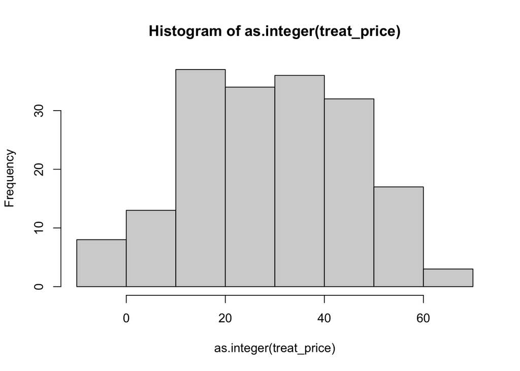

```r
hist(as.integer(treat_price))
```

## Survey Question 8-9

```r
# control
set.seed(3)
cont_buy <- as.factor(rbinom(n = 180,size = 1,prob = 0.5))
cont_buy <- fct_recode(cont_buy,"Yes"="1","No"="0")
fct_count(cont_buy)
```

```
## # A tibble: 2 × 2
##   f         n
##   <fct> <int>
## 1 No       90
## 2 Yes      90
```

```r
# treatment
set.seed(12029)
treat_buy <- as.factor(rbinom(n = 180,size = 1,prob = 0.5))
treat_buy <- fct_recode(treat_buy,"Yes"="1","No"="0")
fct_count(treat_buy)
```

```
## # A tibble: 2 × 2
##   f         n
##   <fct> <int>
## 1 No       93
## 2 Yes      87
```

## Survey Question 10

```r
set.seed(2)
quality <- rnorm(n = 360,mean = 1.5,sd = 0.8)
max(quality);min(quality)
```

```
## [1] 3.810735
```

```
## [1] -0.6761344
```

```r
library(Hmisc);library(dplyr)
quality_sust <- cut(quality,breaks = c(-Inf,1,2,Inf),preset_bins_labels = cut(quality,breaks = c(-Inf,1,2,Inf)),labels =c("Yes","No","I don't Know"))
fct_count(quality_sust)
```

```
## # A tibble: 3 × 2
##   f                n
##   <fct>        <int>
## 1 Yes             90
## 2 No             156
## 3 I don't Know   114
```

# Simulation Dataset

```r
main_data <- data.frame(index = 1:360,often_clothing,sust_agree,sust_pay,info_tags_sust,sust_extra_effort,quality_sust,edu_sust,gender,income_house_sust)
colnames(main_data)
```

```
##  [1] "index"             "often_clothing"    "sust_agree"
##  [4] "sust_pay"          "info_tags_sust"    "sust_extra_effort"
##  [7] "quality_sust"      "edu_sust"          "gender"
## [10] "income_house_sust"
```

```r
set.seed(20)
main_data <- main_data %>%
  mutate(z = row_number() %in% sample(n(), n() / 2) )

skimr::skim(main_data)
```

Data summary

| Name | main_data |
| --- | --- |
| Number of rows | 360 |
| Number of columns | 11 |
| _______________________ |  |
| Column type frequency: |  |
| factor | 9 |
| logical | 1 |
| numeric | 1 |
| ________________________ |  |
| Group variables | None |

**Variable type: factor**

| skim_variable | n_missing | complete_rate | ordered | n_unique | top_counts |
| --- | --- | --- | --- | --- | --- |
| often_clothing | 27 | 0.92 | FALSE | 5 | Abo: 76, A f: 69, Onc: 68, Nev: 67 |
| sust_agree | 12 | 0.97 | FALSE | 5 | Str: 82, Som: 76, Nei: 69, Som: 68 |
| sust_pay | 0 | 1.00 | FALSE | 5 | Str: 193, Som: 84, Nei: 52, Som: 24 |
| info_tags_sust | 0 | 1.00 | FALSE | 5 | Str: 167, Som: 64, Nei: 59, Som: 35 |
| sust_extra_effort | 0 | 1.00 | FALSE | 5 | Str: 136, Som: 68, Nei: 62, Som: 52 |
| quality_sust | 0 | 1.00 | FALSE | 3 | No: 156, I d: 114, Yes: 90 |
| edu_sust | 0 | 1.00 | FALSE | 4 | PHD: 165, Und: 77, Gra: 64, MBA: 54 |
| gender | 0 | 1.00 | FALSE | 2 | Fem: 184, Mal: 176 |
| income_house_sust | 0 | 1.00 | FALSE | 4 | 50-: 159, 180: 145, 0-5: 40, 360: 16 |

**Variable type: logical**

| skim_variable | n_missing | complete_rate | mean | count |
| --- | --- | --- | --- | --- |
| z | 0 | 1 | 0.5 | FAL: 180, TRU: 180 |

**Variable type: numeric**

| skim_variable | n_missing | complete_rate | mean | sd | p0 | p25 | p50 | p75 | p100 | hist |
| --- | --- | --- | --- | --- | --- | --- | --- | --- | --- | --- |
| index | 0 | 1 | 180.5 | 104.07 | 1 | 90.75 | 180.5 | 270.25 | 360 | ▇▇▇▇▇ |

```r
main_data <- main_data |>
  arrange(z)

main_data <- main_data |>
  mutate(price = c(cont_price,treat_price),buy=c(cont_buy,treat_buy))

main_data
```

```
##     index      often_clothing                 sust_agree
## 1       1  About once a month          Somewhat disagree
## 2       4               Never             Strongly agree
## 3       7         Once a year             Somewhat agree
## 4      11               Never             Strongly agree
## 5      15               Never             Strongly agree
## 6      17  A few times a year Neither agree nor disagree
## 7      23  A few times a year Neither agree nor disagree
## 8      24                <NA>                       <NA>
## 9      25         Once a year             Somewhat agree
## 10     27  A few times a year Neither agree nor disagree
## 11     28 Once a week or more          Strongly disagree
## 12     30         Once a year             Somewhat agree
## 13     31               Never             Strongly agree
## 14     32  A few times a year Neither agree nor disagree
```

[output cut: 1429 more lines]

# Statistical Analysis Simulation with no effect

## Research Question 1

```r
main_data |>
  select(z,buy)|>
  table()
```

```
##        buy
## z       No Yes
##   FALSE 90  90
##   TRUE  93  87
```

```r
rq1 <- prop.test(x = c(82,74),n=c(180,180),alternative = "greater")

effect_size_rq1 <- prop.test(x = c(82,74),n=c(180,180),alternative = "greater")$estimate; (effect_size_rq1[1]-effect_size_rq1[2])*100 # in percentage%
```

```
##   prop 1
## 4.444444
```

## Research Question 2

```r
main_data[main_data$z == 1, ]$price
```

```
##   [1] 16 32 53 13 28 31 40 26 59 27 36 44 24 14 56 -4 43 30 45 36 61 12 53 59 30
##  [26] -6 37 21 41 34 41 34 46 25 18 21  4 16 21 26 24  0 17 58 39 59 25 28 27 12
##  [51] 17 60 21 49 14  0 25 44 47 55  3 60 19 32 37 17  0 22 31 16 16 34 27 36 29
##  [76] 16 49 41 45  8 44  4 21  9 -3 57 20 25 24 35 54 55 12  9  7 11 59 30 17 20
## [101] 46 33 25 18 17 60 44 60 23 24 14 26 37 50 38 36 48 47 31 18 48 32 55 23 14
## [126] 38 19 39  4  3 40 34 43  0 48 48 45 41 61  8 21 36 17 31 41 20 39 38 17 15
## [151] 44 27 40 17 49  9 41 36 34 40 35 20 25 35 10 16 61 -1 11 44 46 42 30 34 16
## [176] 20 26 15 42  5
```

```r
rq2 <- t.test(x=main_data[main_data$z == 1, ]$price,y=main_data[main_data$z == 0, ]$price,alternative = "greater")

effect_size_rq2 <- t.test(x=main_data[main_data$z == 1, ]$price,y=main_data[main_data$z == 0, ]$price,alternative = "greater")$estimate; (effect_size_rq2[1]-effect_size_rq2[2])
```

```
##  mean of x
## -0.3808243
```

## Research Question 3

```r
main_data <- main_data %>%
  mutate(price_hilo = factor(ifelse(price >= mean(price), 1, 0), levels = c(0, 1)))
model <- glm(price_hilo~z+edu_sust+income_house_sust+gender,data=main_data, family = "binomial")
pred <- predict(model, type='response')
pred_hilo <- ifelse(pred>0.5, 1, 0)

prop.table(table(pred = pred_hilo, true = main_data$price_hilo))
```

```
##     true
## pred         0         1
##    0 0.2361111 0.1972222
##    1 0.2555556 0.3111111
```

```r
summary(model)
```

```
##
## Call:
## glm(formula = price_hilo ~ z + edu_sust + income_house_sust +
##     gender, family = "binomial", data = main_data)
##
## Deviance Residuals:
##    Min      1Q  Median      3Q     Max
## -1.392  -1.180   1.017   1.157   1.347
##
## Coefficients:
##                           Estimate Std. Error z value Pr(>|z|)
## (Intercept)                0.31385    0.39735   0.790    0.430
## zTRUE                     -0.17085    0.21262  -0.804    0.422
## edu_sustGraduate           0.05551    0.34187   0.162    0.871
## edu_sustMBA               -0.07282    0.35682  -0.204    0.838
## edu_sustPHD               -0.21459    0.27888  -0.769    0.442
## income_house_sust50-180k  -0.21558    0.35735  -0.603    0.546
## income_house_sust180-360k -0.10076    0.36076  -0.279    0.780
## income_house_sust360k+    -0.48935    0.59950  -0.816    0.414
## genderFemale               0.12156    0.21333   0.570    0.569
##
## (Dispersion parameter for binomial family taken to be 1)
##
##     Null deviance: 498.97  on 359  degrees of freedom
## Residual deviance: 496.00  on 351  degrees of freedom
## AIC: 514
##
## Number of Fisher Scoring iterations: 3
```